# PSTAT 131- FINAL PROJECT _YIFAN XU

Yifan Xu

2022-11-27

##INTRODUCTION

The purpose of this project is to generate a model that will predict the possibility of people have heart disease according to his physical data.

What is heart failure?

Heart failure is a heart condition in which the heart cannot pump sufficient blood around the body. This may be due to the heart not filling with enough blood or it is too weak to pump correctly. Despite the name, it does not refer to the heart stopping.

Heart failure usually develops gradually. The heart muscle becomes weaker and has trouble pumping blood to nourish the cells in your body. It is a chronic condition that gradually gets worse. Sometimes, heart failure comes on suddenly after a heart attack as it weakens the heart’s pumping ability. In acute heart failure, the symptoms are usually severe at first. Heart failure symptoms may include coughing up white, pink, or foamy mucus, fatigue and weakness, irregular heartbeat, nausea, lack of appetite, shortness of breath when lying down or exerting energy or fluid retention in the abdomen or extremities. Symptoms may come and go, or they may persist over a period. If new symptoms develop or existing symptoms worsen, it may mean that heart failure is getting worse or that treatment isn’t effective.

Loading Data and Packages

This project uses on a data set of the Heart Failure Prediction, it records information of 5 heart data sets are combined over 11 common features which makes it the largest heart disease dataset available so far for research purposes.

I get this data set from kaggle and the website ishttps://www.kaggle.com/datasets/fedesoriano/heart-failure-prediction. Here are some of the key variables that are helpful to be aware of for this report:

1.Age: age of the patient [years] 2.Sex: sex of the patient [M: Male, F: Female] 3.ChestPainType: chest pain type [TA: Typical Angina, ATA: Atypical Angina, NAP: Non-Anginal Pain, ASY: Asymptomatic] 4.RestingBP: resting blood pressure [mm Hg] 5.Cholesterol: serum cholesterol [mm/dl] 6.FastingBS: fasting blood sugar [1: if FastingBS > 120 mg/dl, 0: otherwise] 7.RestingECG: resting electrocardiogram results [Normal: Normal, ST: having ST-T wave abnormality (T wave inversions and/or ST 8.elevation or depression of > 0.05 mV), LVH: showing probable or definite left ventricular hypertrophy by Estes’ criteria] 9.MaxHR: maximum heart rate achieved [Numeric value between 60 and 202] 10ExerciseAngina: exercise-induced angina [Y: Yes, N: No] 11.Oldpeak: oldpeak = ST [Numeric value measured in depression] 12.ST_Slope: the slope of the peak exercise ST segment [Up: upsloping, Flat: flat, Down: downsloping] 13.HeartDisease: output class [1: heart disease, 0: Normal]

```r
library(tidyverse)
library(tidymodels)
```

```r
library(ISLR)
library(ggplot2)
library(corrplot)
library(ggthemes)
library(yardstick)
library(dplyr)
library(magrittr)
library(corrr)
library(discrim)
library(poissonreg)
library(klaR)
library(janitor)
library(glmnet)
library(rpart.plot)
library(randomForest)
library(ranger)
library(vip)
library(xgboost)
library(ggthemes)
tidymodels_prefer()
set.seed(100)
```

```r
Heart <- read.csv("heart.csv")
head(Heart)
```

```
##   Age Sex ChestPainType RestingBP Cholesterol FastingBS RestingECG MaxHR
## 1  40   M           ATA       140         289         0     Normal   172
## 2  49   F           NAP       160         180         0     Normal   156
## 3  37   M           ATA       130         283         0         ST    98
## 4  48   F           ASY       138         214         0     Normal   108
## 5  54   M           NAP       150         195         0     Normal   122
## 6  39   M           NAP       120         339         0     Normal   170
##   ExerciseAngina Oldpeak ST_Slope HeartDisease
## 1              N     0.0       Up            0
## 2              N     1.0     Flat            1
## 3              N     0.0       Up            0
## 4              Y     1.5     Flat            1
## 5              N     0.0       Up            0
## 6              N     0.0       Up            0
```

## DATA CLEANING

The data set of heart failure that I chosen is tidy, a few different cleaning steps were necessary before the split occurred: there are some observation that do not have Cholesterol values and Restign BP values that shows 0.These skew our results, and thus we are removing them.

```r
Heart = Heart %>%
  filter(Cholesterol != 0) %>%
  filter(RestingBP != 0 )
Heart
```

```
##     Age Sex ChestPainType RestingBP Cholesterol FastingBS RestingECG MaxHR
## 1    40   M           ATA       140         289         0     Normal   172
## 2    49   F           NAP       160         180         0     Normal   156
## 3    37   M           ATA       130         283         0         ST    98
## 4    48   F           ASY       138         214         0     Normal   108
## 5    54   M           NAP       150         195         0     Normal   122
## 6    39   M           NAP       120         339         0     Normal   170
## 7    45   F           ATA       130         237         0     Normal   170
## 8    54   M           ATA       110         208         0     Normal   142
## 9    37   M           ASY       140         207         0     Normal   130
## 10   48   F           ATA       120         284         0     Normal   120
## 11   37   F           NAP       130         211         0     Normal   142
## 12   58   M           ATA       136         164         0         ST    99
## 13   39   M           ATA       120         204         0     Normal   145
## 14   49   M           ASY       140         234         0     Normal   140
```

[output cut: 1479 more lines]

After data cleaning, the total number of observations change from 918 observations to 746 observation.

```r
Heart = Heart %>%
  mutate(Sex = factor(Sex),
         ChestPainType = factor(ChestPainType),
         FastingBS = factor (FastingBS),
         RestingECG = factor(RestingECG),
         ExerciseAngina = factor(ExerciseAngina),
         ST_Slope = factor(ST_Slope),
         HeartDisease = factor(HeartDisease))
Heart
```

```
##     Age Sex ChestPainType RestingBP Cholesterol FastingBS RestingECG MaxHR
## 1    40   M           ATA       140         289         0     Normal   172
## 2    49   F           NAP       160         180         0     Normal   156
## 3    37   M           ATA       130         283         0         ST    98
## 4    48   F           ASY       138         214         0     Normal   108
## 5    54   M           NAP       150         195         0     Normal   122
## 6    39   M           NAP       120         339         0     Normal   170
## 7    45   F           ATA       130         237         0     Normal   170
## 8    54   M           ATA       110         208         0     Normal   142
## 9    37   M           ASY       140         207         0     Normal   130
## 10   48   F           ATA       120         284         0     Normal   120
## 11   37   F           NAP       130         211         0     Normal   142
## 12   58   M           ATA       136         164         0         ST    99
## 13   39   M           ATA       120         204         0     Normal   145
## 14   49   M           ASY       140         234         0     Normal   140
```

[output cut: 1479 more lines]

After data cleaning, all the types of variable are appropriate.

## DATA SPLIT

The data was split in a 80% training, 20% testing split. Stratified sampling was used as the difficulty distribution was skewed.

```r
Heart_split <- Heart %>%
  initial_split(prop = 0.8, strata = HeartDisease)

Heart_train <- training(Heart_split)
Heart_test <- testing(Heart_split)
```

After data split, the training data set has about 596 observations and the testing data set has just under 150 observations.

##Exploratory Data Analysis

This entire exploratory data analysis will be based only on the training set, which has 596 observations. Each observation represents a single class.

AGE

[figure not shown]

```r
ggplot(Heart_train, aes(Age)) +
  geom_histogram(bins = 50, color = "white") +
  labs(
    title = "Histogram of Difficulty"
  )
```

This histogram looks like a normal distribution which is the result i want. Because it shows that all people in different age period.

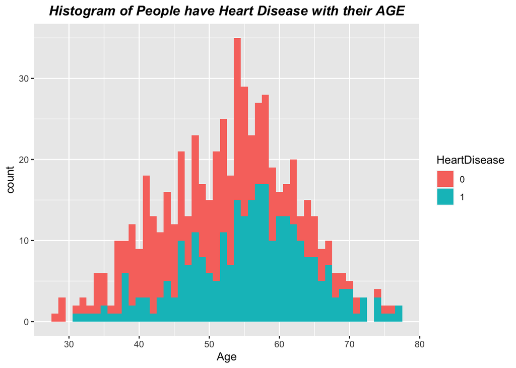

```r
ggplot(Heart_train, aes(x = Age, fill = HeartDisease)) +
  geom_histogram(bins = 50) +
  labs(
    title = "Histogram of People have Heart Disease with their AGE") +
    theme(plot.title = element_text(face = "bold.italic", hjust=0.5))
```

From the result of Histogram of People have Heart Disease with their AGE, we can find that older people have higher rates of heart disease. Especiall when people are older that 60.

##SEX

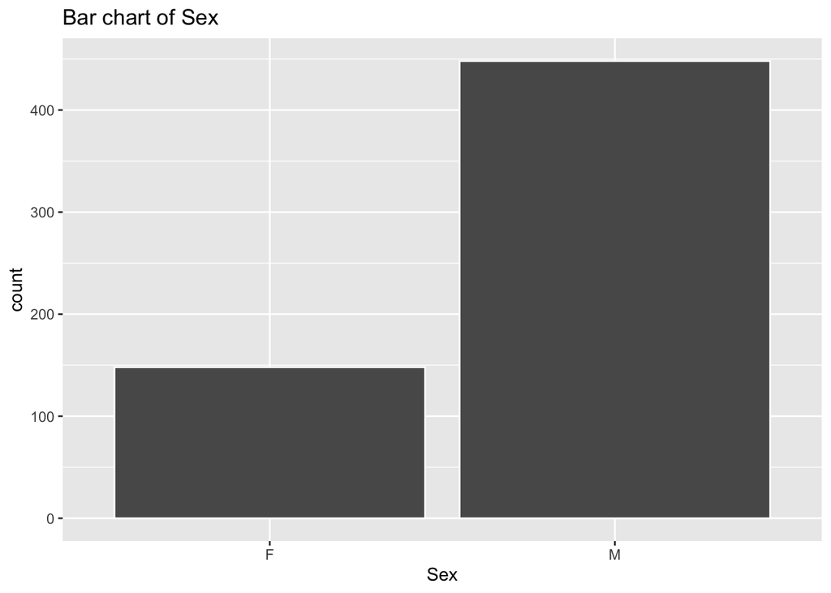

```r
ggplot(Heart_train, aes(Sex)) +
  geom_bar( color = "white") +
  labs(
    title = "Bar chart of Sex"
  )
```

In the training data set, the distribution of Male and Female are not equal or close, so we can not analyse the effect of sex on heart disease.

##ChestPainType

For ChestPainType data, there 4 different types: [TA: Typical Angina, ATA: Atypical Angina, NAP: Non-Anginal Pain, ASY: Asymptomatic].

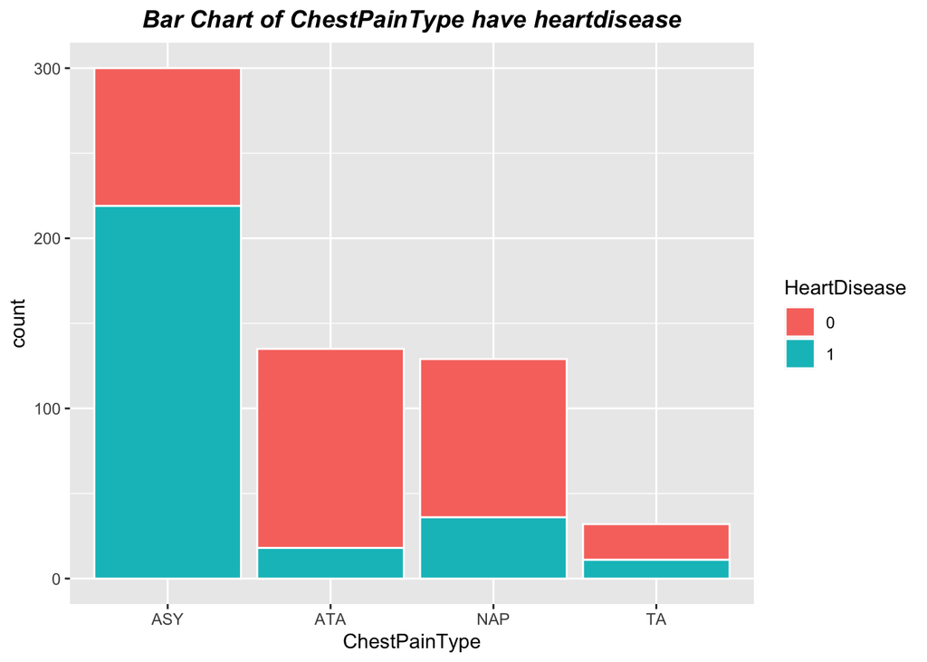

```r
ggplot(Heart_train, aes(x = ChestPainType, fill = HeartDisease)) +
  geom_bar( color = "white") +
  labs(
    title = "Bar Chart of ChestPainType have heartdisease")+
  theme(plot.title = element_text(face = "bold.italic", hjust=0.5))
```

According to the Bar Chart of ChestPainType have heart disease, Only Asymptomatic type shows that has more than 50 percent have heart disease. This data value is far more than the other three types of chest pain.

## Resting BP

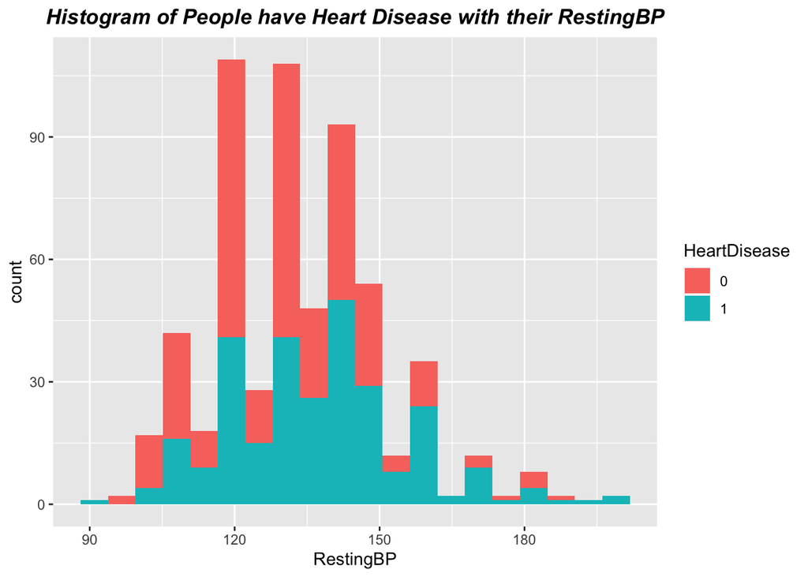

```r
ggplot(Heart_train, aes(x = RestingBP, fill = HeartDisease)) +
  geom_histogram(bins = 20) +
  labs(
    title = "Histogram of People have Heart Disease with their RestingBP") +
    theme(plot.title = element_text(face = "bold.italic", hjust=0.5))
```

Accoring to Histogram of People have Heart Disease with their RestingBP, we noticed that the higher the Restign BP, the higher rate of have HeartDisease.

Then we connect RestingBP and ChestPainType

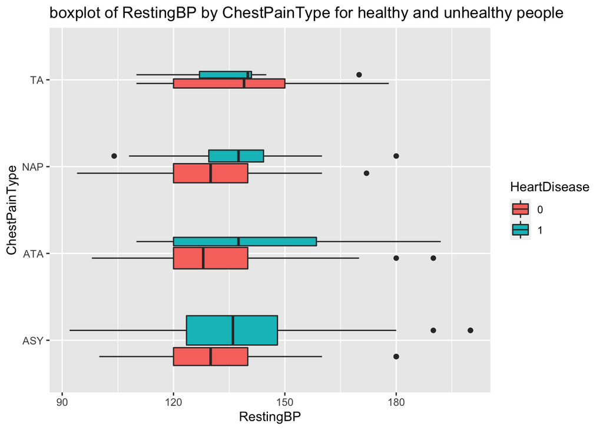

```r
ggplot(Heart_train, aes(ChestPainType, RestingBP,fill = HeartDisease)) +
  geom_boxplot(varwidth = TRUE) +
  coord_flip() +
  labs(
    title = "boxplot of RestingBP by ChestPainType for healthy and unhealthy people ",
    y = "RestingBP",
    x = "ChestPainType"
  )
```

By the box plot above, we find that for all 4 types of chest pain, the mean of people with HeartDisease all higehr than people without HeartDisease. This is the same with our observation that the higher the Restign BP, the higher rate of have HeartDisease. So we can conclude that RestingBP variable is a imporatnt factor of HeartDisease.

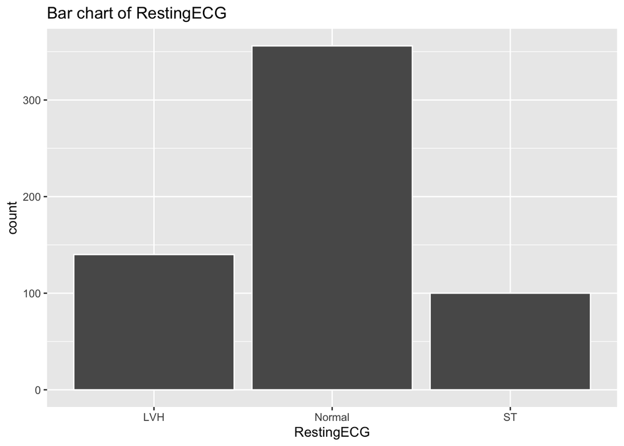

```r
ggplot(Heart_train, aes(RestingECG)) +
  geom_bar( color = "white") +
  labs(
    title = "Bar chart of RestingECG"
  )
```

[figure not shown]

```r
ggplot(Heart_train, aes(x = RestingECG, fill = HeartDisease)) +
  geom_bar( color = "white") +
  labs(
    title = "Bar Chart of ChestPainType")+
  theme(plot.title = element_text(face = "bold.italic", hjust=0.5))
```

[figure not shown]

```r
ggplot(Heart_train, aes(RestingECG, MaxHR )) +
  geom_boxplot(varwidth = TRUE) +
  coord_flip() +
  labs(
    title = "RestingBP by ChestPainType",
    x = "MaxHR"
  )
```

[figure not shown]

```r
ggplot(Heart_train, aes(RestingECG, MaxHR,fill = HeartDisease )) +
  geom_boxplot(varwidth = TRUE) +
  coord_flip() +
  labs(
    title = "RestingBP by ChestPainType",
    x = "RestingECG",
    y="MaxHR"
  )
```

## MAXHR

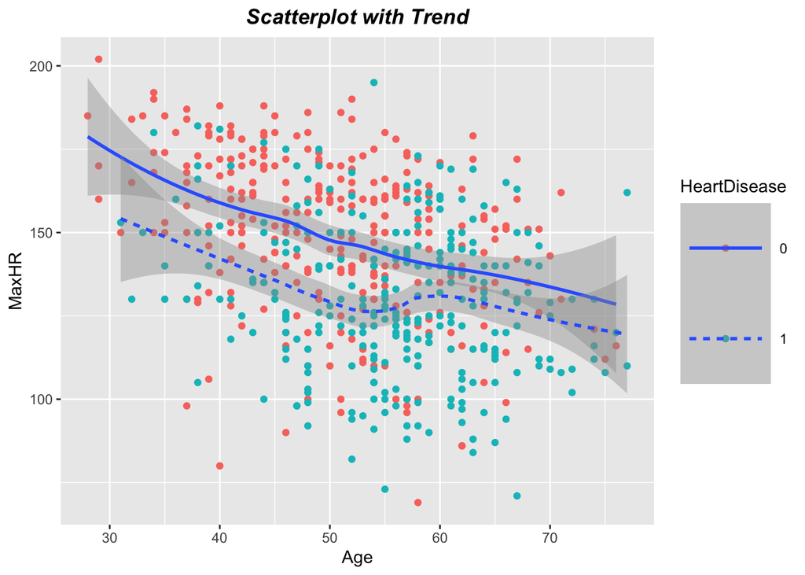

```r
Heart_train %>%
  ggplot(mapping = aes(x = Age, y = MaxHR)) +
  ggtitle("Scatterplot with Trend")+
  geom_point(aes(color = HeartDisease)) +
  geom_smooth(aes(linetype = HeartDisease), se = TRUE)+
  labs(x = "Age", y = "MaxHR")+
  theme( legend.key.size = unit(2, 'cm'),
        plot.title = element_text(face = "bold.italic", hjust=0.5))
```

[figure not shown]

```r
ggplot(Heart_train, aes(ExerciseAngina)) +
  geom_bar( color = "white") +
  labs(
    title = "Bar chart of RestingECG"
  )
```

[figure not shown]

```r
 ggplot(Heart_train, aes(x = ExerciseAngina, fill = HeartDisease)) +
  geom_bar( color = "white") +
  labs(
    title = "Bar Chart of ChestPainType")+
  theme(plot.title = element_text(face = "bold.italic", hjust=0.5))
```

[figure not shown]

```r
ggplot(Heart_train, aes(MaxHR, ExerciseAngina,fill = HeartDisease)) +
  geom_boxplot(varwidth = TRUE) +
  coord_flip() +
  labs(
    title = "RestingBP by ChestPainType",
    x = "MaxHR"
  )
```